# Jupyter ~Python~ for APS Students

Python is more than Jupyter, is a whole language!

Python Tutorial! https://docs.python.org/3/tutorial/ \ Jupyter Notebook: https://jupyter-notebook.readthedocs.io/en/stable/ \ Jupyter's documentation: https://docs.jupyter.org/en/latest/ \ Markdown's cheat sheet: https://www.edureka.co/blog/wp-content/uploads/2018/10/Jupyter_Notebook_CheatSheet_Edureka.pdf

**Troubleshooting**

- Google it!
- Use Stackoverflow.
- Use the documentation.

**Some shortcuts in Jupyter:**

- Markdown mode: Esc + M
- Code mode: Esc + Y
- Insert cell above: A
- Insert cell below: B
- Run current cell: Ctrl + Enter
- Delete current cell: D + D
- Comment: Ctrl + /

## Jupyter Vs. Spyder or PyCharm?

- Depends on you. Notebooks allow you to make reports ready for presentation. More transferable than Spyder/PyCharm
- There are extensions that allow to list current variables and other functions from Spyder
- Not so easy to run single line on Jupyter
- My answer: Jupyter Lab. Includes single line execution

## How about Colab? (Google's version of Jupyter)

- Can open Jupyter Notebooks (.ipynb) files with Colab without need for installing Python or main packages.
- May need to install custom or specific packages using `pip install`
- It may require your consent to access files in your Drive
- X number of hours a month, otherwise you have to pay
- You can decide if you want to use GPU or CPU

# Packages

Mainly `!pip install mypackage` from your Jupyter Notebook, *or* `conda install -c conda-forge mypackage`. Conda seems to work better most times, but sometimes you have to try both. **Just Google it!**

## Some of the main packages:

| Package | Use | Source |
| --- | --- | --- |
| `numpy` | Fundamental package for array computing | https://numpy.org/ |
| `pandas` | Data analysis and manipulation | https://pandas.pydata.org/ |
| `matplotlib` | Static, animated, and interactive visualizations | https://matplotlib.org/ |
| `scikit-learn` | Robust for data analysis and machine learning | https://scikit-learn.org/stable/ |
| `tensorflow` | Implementing neural networks | https://www.tensorflow.org/ |
| `scipy` | Scientific and mathematical funtions derived from `NumPy` | https://scipy.org/ |
| `statsmodels` | Hardcore statistics | https://www.statsmodels.org/stable/index.html |
| `seaborn` | Data analysis and manipulation | https://seaborn.pydata.org/ |
| `scikit-image` | Algorithms for image processing | https://scikit-image.org/ |
| `opencv` | Computer vision, machine learning, and image processing | https://pypi.org/project/opencv-python/ |

# Markdown

```python
# This is a comment in a code mode cell
```

```python
This is an error
```

```
  File "<ipython-input-4-ec1f0368190f>", line 1
    This is an error
               ^
SyntaxError: invalid syntax
```

simple text

## This is a subtitle

Some **bold text** Some *italic text*

Some text with `code` in it

An equation using *LaTeX*:

$y = mx + b$

Another equation:

$$P = G + E + GxE$$

First table:

| Row 0 Column 0 | Row 0 Column 1 | Row 0 Column 2 |
| --- | --- | --- |
| 10 | 11 | 12 |
| 20 | 21 | 22 |
| 30 | 31 | 32 |

Second table:

| Left aligned column | Centered column | Right aligned column |
| --- | --- | --- |
| **Bold data** | *Italic data* | Normal data |
| 20 | 21 | 22 |

Third table?:

| Column 0 | Column 1 | Column 2 |
| --- | --- | --- |
| 00 | 01 | 02 |

# Python as a Calculator

Numbers, Strings, Lists

## Numbers

```python
2 + 2
```

```
4
```

```python
50 - 5*6
```

```
20
```

```python
(50 - 5*6) / 4
```

```
5.0
```

```python
8 / 5  # division always returns a floating point number
```

```
1.6
```

The integer numbers (e.g. 2, 4, 20) have type `int`, the ones with a fractional part (e.g. 5.0, 1.6) have type `float`.

```python
5 ** 2  # 5 squared
```

```
25
```

```python
2 ** 7  # 2 to the power of 7
```

```
128
```

The equal sign (=) is used to assign a value to a variable. Afterwards, no result is displayed before the next interactive prompt:

```python
width = 20
height = 5 * 9
width * height
```

```
900
```

If a variable is not “defined” (assigned a value), trying to use it will give you an error:

```python
n  # try to access an undefined variable
```

```
---------------------------------------------------------------------------
NameError                                 Traceback (most recent call last)
<ipython-input-9-6268bfea6a2c> in <module>
----> 1 n  # try to access an undefined variable

NameError: name 'n' is not defined
```

## Strings

Strings can be enclosed in single quotes ('...') or double quotes ("...").

\ can be used to escape quotes:

```python
'spam eggs'  # single quotes
```

```
'spam eggs'
```

```python
'doesn't'
```

```
  File "<ipython-input-136-f70cf6904edb>", line 1
    'doesn't'
           ^
SyntaxError: invalid syntax
```

```python
'doesn\'t'  # use \' to escape the single quote...
```

```
"doesn't"
```

```python
"doesn't"  # ...or use double quotes instead
```

```
"doesn't"
```

```python
'"Yes," they said.'
```

```
'"Yes," they said.'
```

```python
"\"Yes,\" they said."
```

```
'"Yes," they said.'
```

```python
'"Isn\'t," they said.'
```

```
'"Isn\'t," they said.'
```

```python
'doesn't'
```

```
  File "<ipython-input-33-f70cf6904edb>", line 1
    'doesn't'
           ^
SyntaxError: invalid syntax
```

Strings can be concatenated (glued together) with the + operator, and repeated with *:

```python
# 3 times 'un', followed by 'ium'
3 * 'un' + 'ium'
```

```
'unununium'
```

Strings can be indexed (subscripted), with the first character having index 0. There is no separate character type; a character is simply a string of size one:

```python
word = 'Python'
```

```python
word[0]  # character in position 0, (1st element)
```

```
'P'
```

```python
word[5]  # character in position 5 (6th element)
```

```
'n'
```

Indices may also be negative numbers, to start counting from the right:

```python
word[-1]  # last character
```

```
'n'
```

```python
word[-2]  # second-last character
```

```
'o'
```

```python
word[-6]
```

```
'P'
```

Note that since -0 is the same as 0, negative indices start from -1.

In addition to indexing, slicing is also supported. While indexing is used to obtain individual characters, slicing allows you to obtain substring:

```python
word[0:2]  # characters from position 0 (included) to 2 (excluded)
```

```
'Py'
```

```python
word[2:5]  # characters from position 2 (included) to 5 (excluded)
```

```
'tho'
```

```python
word[:2]   # character from the beginning to position 2 (excluded)
```

```
'Py'
```

```python
word[4:]   # characters from position 4 (included) to the end
```

```
'on'
```

```python
word[-2:]  # characters from the second-last (included) to the end
```

```
'on'
```

Note how the start is always included, and the end always excluded. This makes sure that s[:i] + s[i:] is always equal to s:

```python
word[:2] + word[2:]
```

```
'Python'
```

```python
word[:4] + word[4:]
```

```
'Python'
```

One way to remember how slices work is to think of the indices as pointing between characters, with the left edge of the first character numbered 0. Then the right edge of the last character of a string of n characters has index n, for example:

```
+---+---+---+---+---+---+
 | P | y | t | h | o | n |
 +---+---+---+---+---+---+
 0   1   2   3   4   5   6
-6  -5  -4  -3  -2  -1
```

The first row of numbers gives the position of the indices 0…6 in the string; the second row gives the corresponding negative indices. The slice from i to j consists of all characters between the edges labeled i and j, respectively.

## Lists

Python knows a number of compound data types, used to group together other values. The most versatile is the list, which can be written as a list of comma-separated values (items) between square brackets. Lists might contain items of different types, but usually the items all have the same type.

```python
squares = [1, 4, 9, 16, 25]
squares
```

```
[1, 4, 9, 16, 25]
```

Lists can also be sliced

```python
squares[0]  # indexing returns the item
```

```
1
```

```python
squares[-1]
```

```
25
```

```python
squares[-3:]  # slicing returns a new list
```

```
[9, 16, 25]
```

```python
# Concatenation
squares + [36, 49, 64, 81, 100]
```

```
[1, 4, 9, 16, 25, 36, 49, 64, 81, 100]
```

Unlike strings, which are immutable, lists are a mutable type, i.e. it is possible to change their content:

```python
word[2] = 'g'
```

```
---------------------------------------------------------------------------
TypeError                                 Traceback (most recent call last)
<ipython-input-19-178d021d5a46> in <module>
----> 1 word[2] = 'g'

TypeError: 'str' object does not support item assignment
```

```python
cubes = [1, 8, 27, 65, 125]  # something's wrong here
4 ** 3  # the cube of 4 is 64, not 65!
```

```
64
```

```python
cubes[3] = 64  # replace the wrong value
cubes
```

```
[1, 8, 27, 64, 125]
```

You can also add new items at the end of the list, by using the append() method

```python
cubes.append(216)  # add the cube of 6
cubes
```

```
[1, 8, 27, 64, 125, 216]
```

```python
cubes.append(7 ** 3)  # and the cube of 7
cubes
```

```
[1, 8, 27, 64, 125, 216, 343]
```

Assignment to slices is also possible, and this can even change the size of the list or clear it entirely:

```python
letters = ['a', 'b', 'c', 'd', 'e', 'f', 'g']
letters

# replace some values
letters[2:5] = ['C', 'D', 'E']
letters

# now remove them
letters[2:5] = []
letters

# clear the list by replacing all the elements with an empty list
letters[:] = []
letters
```

[output not shown]

It is possible to nest lists (create lists containing other lists), for example:

```python
a = ['a', 'b', 'c']
n = [1, 2, 3]
x = [a, n]
x
```

```
[['a', 'b', 'c'], [1, 2, 3]]
```

```python
x[0]
```

```
['a', 'b', 'c']
```

```python
x[0][1]
```

```
'b'
```

# First Steps Towards Programming

```python
# Fibonacci series:
# the sum of two elements defines the next
a, b = 0, 1
while a < 10:
    print(a)
    a, b = b, a+b
```

```
0
1
1
2
3
5
8
```

- The first line contains a multiple assignment.
- The while loop executes as long as the condition (here: a < 10) remains true.
- The body of the loop is indented: indentation is Python’s way of grouping statements.
- The print() function writes the value of the argument(s) it is given.

The keyword argument end can be used to avoid the newline after the output, or end the output with a different string:

```python
a, b = 0, 1
while a < 1000:
    print(a, end=',')
    a, b = b, a+b
```

```
0,1,1,2,3,5,8,13,21,34,55,89,144,233,377,610,987,
```

Avoid infinite loops!

## What's wrong here?

```python
a, b = 0, 1
while a < 10
    print(a)
    a, b = b, a+b
```

```
  File "<ipython-input-32-d70d754b0bf3>", line 2
    while a < 10
                ^
SyntaxError: invalid syntax
```

```python
a = 0
b = 1
while a < 10:
    print(a)
     a, b = b, a+b
```

```
  File "<ipython-input-39-dd38c3f3480c>", line 5
    a, b = b, a+b
    ^
IndentationError: unexpected indent
```

## Control Flow Tools

### `if` Statements

```python
x = int(input("Please enter an integer: "))

if x < 0:
    x = 0
    print('Negative changed to zero')
elif x == 0:
    print('Zero')
elif x == 1:
    print('Single')
else:
    print('More')
```

```
Zero
```

### `for` Statements

```python
# Measure some strings:
words = ['cat', 'window', 'defenestrate']
for w in words:
    print(w, len(w))
```

```
cat 3
window 6
defenestrate 12
```

### The `range()` Function

If you do need to iterate over a sequence of numbers, the built-in function range() comes in handy. It generates arithmetic progressions:

```python
for i in range(5):
    print(i)
```

```
0
1
2
3
4
```

```python
list(range(5, 10))
```

```
[5, 6, 7, 8, 9]
```

```python
list(range(0, 10, 3))
```

```
[0, 3, 6, 9]
```

```python
list(range(-10, -100, -30))
```

```
[-10, -40, -70]
```

```python
a = ['Mary', 'had', 'a', 'little', 'lamb']
for i in range(len(a)):
    print(i, a[i])
```

```
0 Mary
1 had
2 a
3 little
4 lamb
```

```python
range(10)
```

```
range(0, 10)
```

In many ways the object returned by range() behaves as if it is a list, but in fact it isn’t. It is an object which returns the successive items of the desired sequence when you iterate over it, but it doesn’t really make the list, thus saving space.

```python
sum(range(4))  # 0 + 1 + 2 + 3
```

```
6
```

# Defining Functions

```python
def fib(n):    # write Fibonacci series up to n
    """Print a Fibonacci series up to n."""
    a, b = 0, 1
    while a < n:
        print(a, end=' ')
        a, b = b, a+b
    print()

# Now call the function we just defined:
fib(2000)
```

```
0 1 1 2 3 5 8 13 21 34 55 89 144 233 377 610 987 1597
```

```python
fib
```

```
<function __main__.fib(n)>
```

```python
f = fib
f(100)
```

```
0 1 1 2 3 5 8 13 21 34 55 89
```

```python
def fib2(n):  # return Fibonacci series up to n
    """Return a list containing the Fibonacci series up to n."""
    result = []
    a, b = 0, 1
    while a < n:
        result.append(a)    # see below
        a, b = b, a+b
    return result
                # write the result
```

```python
f100 = fib2(100)    # call it
f100
```

```
[0, 1, 1, 2, 3, 5, 8, 13, 21, 34, 55, 89]
```

# Data Wrangling with Pandas

Source: https://pandas.pydata.org/pandas-docs/stable/user_guide/10min.html

Pandas cheat sheet: https://pandas.pydata.org/Pandas_Cheat_Sheet.pdf

```python
# Import packages
import numpy as np
import pandas as pd
```

Creating a Series by passing a list of values, letting pandas create a default integer index:

```python
s = pd.Series([1, 3, 5, np.nan, 6, 8])
s
```

```
0    1.0
1    3.0
2    5.0
3    NaN
4    6.0
5    8.0
dtype: float64
```

Creating a DataFrame by passing a NumPy array, with a datetime index and labeled columns:

```python
dates = pd.date_range("20130101", periods=6)
dates
```

```
DatetimeIndex(['2013-01-01', '2013-01-02', '2013-01-03', '2013-01-04',
               '2013-01-05', '2013-01-06'],
              dtype='datetime64[ns]', freq='D')
```

```python
df = pd.DataFrame(np.random.randn(6, 4), index=dates, columns=list("ABCD"))
df
```

|  | A | B | C | D |
| --- | --- | --- | --- | --- |
| 2013-01-01 | -1.480452 | -0.172940 | 1.338613 | -1.720788 |
| 2013-01-02 | -0.037848 | -0.530632 | -0.217937 | -0.536447 |
| 2013-01-03 | 0.433274 | -0.806164 | -0.215045 | 0.941992 |
| 2013-01-04 | 0.142305 | 1.114357 | 0.266428 | -0.473880 |
| 2013-01-05 | 1.078153 | 3.061315 | -0.481994 | -1.873448 |
| 2013-01-06 | 0.514207 | -0.047657 | -0.304217 | 0.668869 |

Creating a DataFrame by passing a dictionary of objects that can be converted into a series-like structure:

```python
df2 = pd.DataFrame(
    {
        "A": 1.0,
        "B": pd.Timestamp("20130102"),
        "C": pd.Series(1, index=list(range(4)), dtype="float32"),
        "D": np.array([3] * 4, dtype="int32"),
        "E": pd.Categorical(["test", "train", "test", "train"]),
        "F": "foo",
    }
)

df2
```

|  | A | B | C | D | E | F |
| --- | --- | --- | --- | --- | --- | --- |
| 0 | 1.0 | 2013-01-02 | 1.0 | 3 | test | foo |
| 1 | 1.0 | 2013-01-02 | 1.0 | 3 | train | foo |
| 2 | 1.0 | 2013-01-02 | 1.0 | 3 | test | foo |
| 3 | 1.0 | 2013-01-02 | 1.0 | 3 | train | foo |

```python
df2.dtypes
```

```
A           float64
B    datetime64[ns]
C           float32
D             int32
E          category
F            object
dtype: object
```

```python
# Use tab autocomplete
df2.duplicated
```

```
<bound method DataFrame.duplicated of      A          B    C  D      E    F
0  1.0 2013-01-02  1.0  3   test  foo
1  1.0 2013-01-02  1.0  3  train  foo
2  1.0 2013-01-02  1.0  3   test  foo
3  1.0 2013-01-02  1.0  3  train  foo>
```

```python
df2.<TAB>  # noqa: E225, E999
```

```
  File "<ipython-input-65-2e62111f8e28>", line 1
    df2.<TAB>  # noqa: E225, E999
        ^
SyntaxError: invalid syntax
```

## Viewing data

```python
df.head()
```

[output not shown]

```python
df.tail(3)
```

[output not shown]

```python
df.index
```

```
DatetimeIndex(['2013-01-01', '2013-01-02', '2013-01-03', '2013-01-04',
               '2013-01-05', '2013-01-06'],
              dtype='datetime64[ns]', freq='D')
```

```python
df.columns
```

```
Index(['A', 'B', 'C', 'D'], dtype='object')
```

```python
df.to_numpy()
```

[output not shown]

```python
df2.to_numpy()
```

```
array([[1.0, Timestamp('2013-01-02 00:00:00'), 1.0, 3, 'test', 'foo'],
       [1.0, Timestamp('2013-01-02 00:00:00'), 1.0, 3, 'train', 'foo'],
       [1.0, Timestamp('2013-01-02 00:00:00'), 1.0, 3, 'test', 'foo'],
       [1.0, Timestamp('2013-01-02 00:00:00'), 1.0, 3, 'train', 'foo']],
      dtype=object)
```

```python
df.describe()
```

[output not shown]

```python
df.T
```

|  | 2013-01-01 | 2013-01-02 | 2013-01-03 | 2013-01-04 | 2013-01-05 | 2013-01-06 |
| --- | --- | --- | --- | --- | --- | --- |
| A | -1.480452 | -0.037848 | 0.433274 | 0.142305 | 1.078153 | 0.514207 |
| B | -0.172940 | -0.530632 | -0.806164 | 1.114357 | 3.061315 | -0.047657 |
| C | 1.338613 | -0.217937 | -0.215045 | 0.266428 | -0.481994 | -0.304217 |
| D | -1.720788 | -0.536447 | 0.941992 | -0.473880 | -1.873448 | 0.668869 |

```python
df.sort_values(by="B")
```

|  | A | B | C | D |
| --- | --- | --- | --- | --- |
| 2013-01-03 | 0.433274 | -0.806164 | -0.215045 | 0.941992 |
| 2013-01-02 | -0.037848 | -0.530632 | -0.217937 | -0.536447 |
| 2013-01-01 | -1.480452 | -0.172940 | 1.338613 | -1.720788 |
| 2013-01-06 | 0.514207 | -0.047657 | -0.304217 | 0.668869 |
| 2013-01-04 | 0.142305 | 1.114357 | 0.266428 | -0.473880 |
| 2013-01-05 | 1.078153 | 3.061315 | -0.481994 | -1.873448 |

## Getting

```python
df["A"]
```

```
2013-01-01   -1.480452
2013-01-02   -0.037848
2013-01-03    0.433274
2013-01-04    0.142305
2013-01-05    1.078153
2013-01-06    0.514207
Freq: D, Name: A, dtype: float64
```

```python
df[0:3]
```

|  | A | B | C | D |
| --- | --- | --- | --- | --- |
| 2013-01-01 | -1.480452 | -0.172940 | 1.338613 | -1.720788 |
| 2013-01-02 | -0.037848 | -0.530632 | -0.217937 | -0.536447 |
| 2013-01-03 | 0.433274 | -0.806164 | -0.215045 | 0.941992 |

```python
df["20130102":"20130104"]
```

|  | A | B | C | D |
| --- | --- | --- | --- | --- |
| 2013-01-02 | -0.037848 | -0.530632 | -0.217937 | -0.536447 |
| 2013-01-03 | 0.433274 | -0.806164 | -0.215045 | 0.941992 |
| 2013-01-04 | 0.142305 | 1.114357 | 0.266428 | -0.473880 |

### Selection by label

```python
df.loc[dates[0]]
```

```
A   -1.480452
B   -0.172940
C    1.338613
D   -1.720788
Name: 2013-01-01 00:00:00, dtype: float64
```

```python
df.loc[:, ["A", "B"]]
```

|  | A | B |
| --- | --- | --- |
| 2013-01-01 | -1.480452 | -0.172940 |
| 2013-01-02 | -0.037848 | -0.530632 |
| 2013-01-03 | 0.433274 | -0.806164 |
| 2013-01-04 | 0.142305 | 1.114357 |
| 2013-01-05 | 1.078153 | 3.061315 |
| 2013-01-06 | 0.514207 | -0.047657 |

```python
df.loc["20130102":"20130104", ["A", "B"]]
```

|  | A | B |
| --- | --- | --- |
| 2013-01-02 | -0.037848 | -0.530632 |
| 2013-01-03 | 0.433274 | -0.806164 |
| 2013-01-04 | 0.142305 | 1.114357 |

```python
df.loc["20130102", ["A", "B"]]
```

```
A   -0.037848
B   -0.530632
Name: 2013-01-02 00:00:00, dtype: float64
```

```python
df.loc[dates[0], "A"]
```

```
-1.4804524704022644
```

### Selection by position

```python
df.iloc[3]
```

```
A    0.142305
B    1.114357
C    0.266428
D   -0.473880
Name: 2013-01-04 00:00:00, dtype: float64
```

```python
df.iloc[3:5, 0:2]
```

|  | A | B |
| --- | --- | --- |
| 2013-01-04 | 0.142305 | 1.114357 |
| 2013-01-05 | 1.078153 | 3.061315 |

```python
df.iloc[[1, 2, 4], [0, 2]]
```

|  | A | C |
| --- | --- | --- |
| 2013-01-02 | -0.037848 | -0.217937 |
| 2013-01-03 | 0.433274 | -0.215045 |
| 2013-01-05 | 1.078153 | -0.481994 |

```python
df.iloc[1:3, :]
```

|  | A | B | C | D |
| --- | --- | --- | --- | --- |
| 2013-01-02 | -0.037848 | -0.530632 | -0.217937 | -0.536447 |
| 2013-01-03 | 0.433274 | -0.806164 | -0.215045 | 0.941992 |

```python
df.iloc[:, 1:3]
```

[output not shown]

```python
df.iloc[1, 1]
```

```
-0.5306323247432938
```

### Boolean indexing

```python
df[df["A"] > 0]
```

|  | A | B | C | D |
| --- | --- | --- | --- | --- |
| 2013-01-03 | 0.433274 | -0.806164 | -0.215045 | 0.941992 |
| 2013-01-04 | 0.142305 | 1.114357 | 0.266428 | -0.473880 |
| 2013-01-05 | 1.078153 | 3.061315 | -0.481994 | -1.873448 |
| 2013-01-06 | 0.514207 | -0.047657 | -0.304217 | 0.668869 |

```python
df[df > 0]
```

|  | A | B | C | D |
| --- | --- | --- | --- | --- |
| 2013-01-01 | NaN | NaN | 1.338613 | NaN |
| 2013-01-02 | NaN | NaN | NaN | NaN |
| 2013-01-03 | 0.433274 | NaN | NaN | 0.941992 |
| 2013-01-04 | 0.142305 | 1.114357 | 0.266428 | NaN |
| 2013-01-05 | 1.078153 | 3.061315 | NaN | NaN |
| 2013-01-06 | 0.514207 | NaN | NaN | 0.668869 |

Using the `isin()` method for filtering:

```python
df2 = df.copy()
```

```python
df2["E"] = ["one", "one", "two", "three", "four", "three"]
df2
```

|  | A | B | C | D | E |
| --- | --- | --- | --- | --- | --- |
| 2013-01-01 | -1.480452 | -0.172940 | 1.338613 | -1.720788 | one |
| 2013-01-02 | -0.037848 | -0.530632 | -0.217937 | -0.536447 | one |
| 2013-01-03 | 0.433274 | -0.806164 | -0.215045 | 0.941992 | two |
| 2013-01-04 | 0.142305 | 1.114357 | 0.266428 | -0.473880 | three |
| 2013-01-05 | 1.078153 | 3.061315 | -0.481994 | -1.873448 | four |
| 2013-01-06 | 0.514207 | -0.047657 | -0.304217 | 0.668869 | three |

```python
df2[df2["E"].isin(["two", "four"])]
```

|  | A | B | C | D | E |
| --- | --- | --- | --- | --- | --- |
| 2013-01-03 | 0.433274 | -0.806164 | -0.215045 | 0.941992 | two |
| 2013-01-05 | 1.078153 | 3.061315 | -0.481994 | -1.873448 | four |

### Missing data

```python
df1 = df.reindex(index=dates[0:4], columns=list(df.columns) + ["E"])
df1
```

|  | A | B | C | D | E |
| --- | --- | --- | --- | --- | --- |
| 2013-01-01 | -1.480452 | -0.172940 | 1.338613 | -1.720788 | NaN |
| 2013-01-02 | -0.037848 | -0.530632 | -0.217937 | -0.536447 | NaN |
| 2013-01-03 | 0.433274 | -0.806164 | -0.215045 | 0.941992 | NaN |
| 2013-01-04 | 0.142305 | 1.114357 | 0.266428 | -0.473880 | NaN |

```python
df1.loc[dates[0] : dates[1], "E"] = 1
df1
```

|  | A | B | C | D | E |
| --- | --- | --- | --- | --- | --- |
| 2013-01-01 | -1.480452 | -0.172940 | 1.338613 | -1.720788 | 1.0 |
| 2013-01-02 | -0.037848 | -0.530632 | -0.217937 | -0.536447 | 1.0 |
| 2013-01-03 | 0.433274 | -0.806164 | -0.215045 | 0.941992 | NaN |
| 2013-01-04 | 0.142305 | 1.114357 | 0.266428 | -0.473880 | NaN |

```python
df1.dropna(how="any")
```

|  | A | B | C | D | E |
| --- | --- | --- | --- | --- | --- |
| 2013-01-01 | -1.480452 | -0.172940 | 1.338613 | -1.720788 | 1.0 |
| 2013-01-02 | -0.037848 | -0.530632 | -0.217937 | -0.536447 | 1.0 |

```python
df1.fillna(value=5)
```

|  | A | B | C | D | E |
| --- | --- | --- | --- | --- | --- |
| 2013-01-01 | -1.480452 | -0.172940 | 1.338613 | -1.720788 | 1.0 |
| 2013-01-02 | -0.037848 | -0.530632 | -0.217937 | -0.536447 | 1.0 |
| 2013-01-03 | 0.433274 | -0.806164 | -0.215045 | 0.941992 | 5.0 |
| 2013-01-04 | 0.142305 | 1.114357 | 0.266428 | -0.473880 | 5.0 |

```python
pd.isna(df1)
```

|  | A | B | C | D | E |
| --- | --- | --- | --- | --- | --- |
| 2013-01-01 | False | False | False | False | False |
| 2013-01-02 | False | False | False | False | False |
| 2013-01-03 | False | False | False | False | True |
| 2013-01-04 | False | False | False | False | True |

### Operations

```python
df.mean()
```

```
A    0.108273
B    0.436380
C    0.064308
D   -0.498951
dtype: float64
```

```python
df.mean(1)
```

```
2013-01-01   -0.508892
2013-01-02   -0.330716
2013-01-03    0.088514
2013-01-04    0.262302
2013-01-05    0.446006
2013-01-06    0.207801
Freq: D, dtype: float64
```

## Merge

### Concat

```python
df = pd.DataFrame(np.random.randn(10, 4))
df
```

|  | 0 | 1 | 2 | 3 |
| --- | --- | --- | --- | --- |
| 0 | -1.169111 | -0.167158 | -0.718803 | 0.592357 |
| 1 | 0.414016 | -0.528987 | 0.030862 | -1.146153 |
| 2 | -0.208096 | -1.425757 | 0.942949 | 1.505157 |
| 3 | 1.988276 | 0.213760 | -0.197728 | 0.180306 |
| 4 | 2.569616 | 0.995275 | 1.058777 | -0.371477 |
| 5 | -1.506504 | -0.481777 | 1.003123 | -2.008509 |
| 6 | 0.360019 | -0.081260 | 0.132758 | -1.652323 |
| 7 | -1.412217 | -1.001344 | -1.879179 | 0.148483 |
| 8 | 0.226984 | 1.107337 | -1.454566 | 1.475884 |
| 9 | -0.148574 | 1.420113 | 0.230315 | 1.365007 |

```python
pieces = [df[:3], df[3:7], df[7:]]
pieces
```

```
[          0         1         2         3
 0 -1.169111 -0.167158 -0.718803  0.592357
 1  0.414016 -0.528987  0.030862 -1.146153
 2 -0.208096 -1.425757  0.942949  1.505157,
           0         1         2         3
 3  1.988276  0.213760 -0.197728  0.180306
 4  2.569616  0.995275  1.058777 -0.371477
 5 -1.506504 -0.481777  1.003123 -2.008509
 6  0.360019 -0.081260  0.132758 -1.652323,
           0         1         2         3
 7 -1.412217 -1.001344 -1.879179  0.148483
 8  0.226984  1.107337 -1.454566  1.475884
 9 -0.148574  1.420113  0.230315  1.365007]
```

```python
pd.concat(pieces)
```

|  | 0 | 1 | 2 | 3 |
| --- | --- | --- | --- | --- |
| 0 | -1.169111 | -0.167158 | -0.718803 | 0.592357 |
| 1 | 0.414016 | -0.528987 | 0.030862 | -1.146153 |
| 2 | -0.208096 | -1.425757 | 0.942949 | 1.505157 |
| 3 | 1.988276 | 0.213760 | -0.197728 | 0.180306 |
| 4 | 2.569616 | 0.995275 | 1.058777 | -0.371477 |
| 5 | -1.506504 | -0.481777 | 1.003123 | -2.008509 |
| 6 | 0.360019 | -0.081260 | 0.132758 | -1.652323 |
| 7 | -1.412217 | -1.001344 | -1.879179 | 0.148483 |
| 8 | 0.226984 | 1.107337 | -1.454566 | 1.475884 |
| 9 | -0.148574 | 1.420113 | 0.230315 | 1.365007 |

### Join

```python
left = pd.DataFrame({"key": ["foo", "foo"], "lval": [1, 2]})
left
```

|  | key | lval |
| --- | --- | --- |
| 0 | foo | 1 |
| 1 | foo | 2 |

```python
right = pd.DataFrame({"key": ["foo", "foo"], "rval": [4, 5]})
right
```

|  | key | rval |
| --- | --- | --- |
| 0 | foo | 4 |
| 1 | foo | 5 |

```python
pd.merge(left, right, on="key")
```

|  | key | lval | rval |
| --- | --- | --- | --- |
| 0 | foo | 1 | 4 |
| 1 | foo | 1 | 5 |
| 2 | foo | 2 | 4 |
| 3 | foo | 2 | 5 |

```python
left = pd.DataFrame({"key": ["foo", "bar"], "lval": [1, 2]})
left
```

|  | key | lval |
| --- | --- | --- |
| 0 | foo | 1 |
| 1 | bar | 2 |

```python
right = pd.DataFrame({"key": ["foo", "bar"], "rval": [4, 5]})
right
```

|  | key | rval |
| --- | --- | --- |
| 0 | foo | 4 |
| 1 | bar | 5 |

```python
pd.merge(left, right, on="key")
```

|  | key | lval | rval |
| --- | --- | --- | --- |
| 0 | foo | 1 | 4 |
| 1 | bar | 2 | 5 |

## Grouping

```python
df = pd.DataFrame(
    {
        "A": ["foo", "bar", "foo", "bar", "foo", "bar", "foo", "foo"],
        "B": ["one", "one", "two", "three", "two", "two", "one", "three"],
        "C": np.random.randn(8),
        "D": np.random.randn(8),
    }
)

df
```

|  | A | B | C | D |
| --- | --- | --- | --- | --- |
| 0 | foo | one | 0.022709 | -0.046414 |
| 1 | bar | one | -0.442514 | -1.018832 |
| 2 | foo | two | 0.459776 | -0.587848 |
| 3 | bar | three | -0.847166 | -0.008629 |
| 4 | foo | two | 0.225504 | 0.534603 |
| 5 | bar | two | -0.162521 | 2.285249 |
| 6 | foo | one | 1.703262 | -0.808704 |
| 7 | foo | three | -1.163584 | 0.506791 |

```python
df.groupby("A").sum()
```

| A | C | D |
| --- | --- | --- |
| bar | -1.452202 | 1.257789 |
| foo | 1.247667 | -0.401573 |

```python
df.groupby(["A", "B"]).sum()
```

| A | B | C | D |
| --- | --- | --- | --- |
| bar | one | -0.442514 | -1.018832 |
|  | three | -0.847166 | -0.008629 |
|  | two | -0.162521 | 2.285249 |
| foo | one | 1.725971 | -0.855119 |
|  | three | -1.163584 | 0.506791 |
|  | two | 0.685280 | -0.053245 |

## Plotting

```python
import matplotlib.pyplot as plt
```

```python
plt.close("all")
```

```python
ts = pd.Series(np.random.randn(1000), index=pd.date_range("1/1/2000", periods=1000))
ts
```

```
2000-01-01   -1.760099
2000-01-02    1.601059
2000-01-03   -2.839054
2000-01-04   -1.894550
2000-01-05    0.131436
                ...
2002-09-22   -0.041256
2002-09-23   -0.114963
2002-09-24    1.417989
2002-09-25   -0.319916
2002-09-26   -0.210146
Freq: D, Length: 1000, dtype: float64
```

```python
ts = ts.cumsum()
ts
```

```
2000-01-01    -1.760099
2000-01-02    -0.159040
2000-01-03    -2.998094
2000-01-04    -4.892645
2000-01-05    -4.761209
                ...
2002-09-22    27.295182
2002-09-23    27.180219
2002-09-24    28.598208
2002-09-25    28.278292
2002-09-26    28.068146
Freq: D, Length: 1000, dtype: float64
```

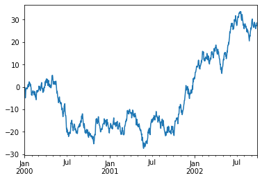

```python
ts.plot();
```

```python
plt.show();
```

```python
df = pd.DataFrame(
    np.random.randn(1000, 4), index=ts.index, columns=["A", "B", "C", "D"]
)
df
```

|  | A | B | C | D |
| --- | --- | --- | --- | --- |
| 2000-01-01 | -0.556687 | -1.872993 | -1.005450 | -0.015538 |
| 2000-01-02 | -0.017468 | -0.900100 | -0.645311 | -0.511213 |
| 2000-01-03 | 0.042295 | 0.692854 | 0.821770 | -0.470240 |
| 2000-01-04 | 0.022575 | 0.932129 | 0.520876 | -0.341525 |
| 2000-01-05 | -0.586326 | 0.503785 | -0.159489 | -1.189842 |
| ... | ... | ... | ... | ... |
| 2002-09-22 | -0.160034 | -0.119460 | 0.707060 | 0.368614 |
| 2002-09-23 | -0.262491 | 0.483600 | -0.342878 | 0.036369 |
| 2002-09-24 | 1.322662 | -0.078108 | -0.113640 | 0.626287 |
| 2002-09-25 | 1.081361 | -1.464355 | -1.427823 | -1.279011 |
| 2002-09-26 | 0.008107 | 0.366092 | -1.778858 | 0.105978 |

1000 rows × 4 columns

```python
df = df.cumsum()
df
```

|  | A | B | C | D |
| --- | --- | --- | --- | --- |
| 2000-01-01 | -0.556687 | -1.872993 | -1.005450 | -0.015538 |
| 2000-01-02 | -0.574155 | -2.773093 | -1.650761 | -0.526751 |
| 2000-01-03 | -0.531860 | -2.080239 | -0.828990 | -0.996991 |
| 2000-01-04 | -0.509285 | -1.148109 | -0.308115 | -1.338516 |
| 2000-01-05 | -1.095612 | -0.644325 | -0.467604 | -2.528358 |
| ... | ... | ... | ... | ... |
| 2002-09-22 | -4.087356 | 10.773764 | 26.978633 | 15.809941 |
| 2002-09-23 | -4.349847 | 11.257364 | 26.635755 | 15.846311 |
| 2002-09-24 | -3.027185 | 11.179256 | 26.522115 | 16.472598 |
| 2002-09-25 | -1.945824 | 9.714901 | 25.094293 | 15.193587 |
| 2002-09-26 | -1.937717 | 10.080993 | 23.315434 | 15.299565 |

1000 rows × 4 columns

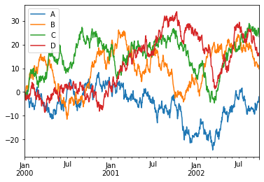

```python
plt.figure();
df.plot();
plt.legend(loc='best');
```

## Getting data in/out

Check current directory

```python
pwd
```

```
'C:\\Users\\jbarreto\\Google Drive\\PROJECTS\\Python4APS\\Python4APS'
```

Write csv

```python
df.to_csv("foo.csv")
```

Read csv

```python
pd.read_csv("foo.csv")
```

|  | Unnamed: 0 | A | B | C | D |
| --- | --- | --- | --- | --- | --- |
| 0 | 2000-01-01 | -0.556687 | -1.872993 | -1.005450 | -0.015538 |
| 1 | 2000-01-02 | -0.574155 | -2.773093 | -1.650761 | -0.526751 |
| 2 | 2000-01-03 | -0.531860 | -2.080239 | -0.828990 | -0.996991 |
| 3 | 2000-01-04 | -0.509285 | -1.148109 | -0.308115 | -1.338516 |
| 4 | 2000-01-05 | -1.095612 | -0.644325 | -0.467604 | -2.528358 |
| ... | ... | ... | ... | ... | ... |
| 995 | 2002-09-22 | -4.087356 | 10.773764 | 26.978633 | 15.809941 |
| 996 | 2002-09-23 | -4.349847 | 11.257364 | 26.635755 | 15.846311 |
| 997 | 2002-09-24 | -3.027185 | 11.179256 | 26.522115 | 16.472598 |
| 998 | 2002-09-25 | -1.945824 | 9.714901 | 25.094293 | 15.193587 |
| 999 | 2002-09-26 | -1.937717 | 10.080993 | 23.315434 | 15.299565 |

1000 rows × 5 columns

Write Excel file

```python
df.to_excel("foo.xlsx", sheet_name="Sheet1")
```

Read Excel file

```python
pd.read_excel("foo.xlsx", "Sheet1", index_col=None, na_values=["NA"])
```

|  | Unnamed: 0 | A | B | C | D |
| --- | --- | --- | --- | --- | --- |
| 0 | 2000-01-01 | -0.556687 | -1.872993 | -1.005450 | -0.015538 |
| 1 | 2000-01-02 | -0.574155 | -2.773093 | -1.650761 | -0.526751 |
| 2 | 2000-01-03 | -0.531860 | -2.080239 | -0.828990 | -0.996991 |
| 3 | 2000-01-04 | -0.509285 | -1.148109 | -0.308115 | -1.338516 |
| 4 | 2000-01-05 | -1.095612 | -0.644325 | -0.467604 | -2.528358 |
| ... | ... | ... | ... | ... | ... |
| 995 | 2002-09-22 | -4.087356 | 10.773764 | 26.978633 | 15.809941 |
| 996 | 2002-09-23 | -4.349847 | 11.257364 | 26.635755 | 15.846311 |
| 997 | 2002-09-24 | -3.027185 | 11.179256 | 26.522115 | 16.472598 |
| 998 | 2002-09-25 | -1.945824 | 9.714901 | 25.094293 | 15.193587 |
| 999 | 2002-09-26 | -1.937717 | 10.080993 | 23.315434 | 15.299565 |

1000 rows × 5 columns

## More Pandas

```python
df = pd.read_csv("foo.csv")
df
```

|  | Unnamed: 0 | A | B | C | D |
| --- | --- | --- | --- | --- | --- |
| 0 | 2000-01-01 | -0.556687 | -1.872993 | -1.005450 | -0.015538 |
| 1 | 2000-01-02 | -0.574155 | -2.773093 | -1.650761 | -0.526751 |
| 2 | 2000-01-03 | -0.531860 | -2.080239 | -0.828990 | -0.996991 |
| 3 | 2000-01-04 | -0.509285 | -1.148109 | -0.308115 | -1.338516 |
| 4 | 2000-01-05 | -1.095612 | -0.644325 | -0.467604 | -2.528358 |
| ... | ... | ... | ... | ... | ... |
| 995 | 2002-09-22 | -4.087356 | 10.773764 | 26.978633 | 15.809941 |
| 996 | 2002-09-23 | -4.349847 | 11.257364 | 26.635755 | 15.846311 |
| 997 | 2002-09-24 | -3.027185 | 11.179256 | 26.522115 | 16.472598 |
| 998 | 2002-09-25 | -1.945824 | 9.714901 | 25.094293 | 15.193587 |
| 999 | 2002-09-26 | -1.937717 | 10.080993 | 23.315434 | 15.299565 |

1000 rows × 5 columns

```python
# Genotypes = ['G01'] * 3 + ['G02'] * 3 + ['G03'] * 3 + ['G04'] * 3
# Genotypes
```

```python
Genotypes = ['G01'] * 250 + ['G02'] * 250 + ['G03'] * 250 + ['G04'] * 250
# Genotypes
```

```python
df['Genotypes'] = Genotypes
```

```python
df
```

|  | Unnamed: 0 | A | B | C | D | Genotypes |
| --- | --- | --- | --- | --- | --- | --- |
| 0 | 2000-01-01 | -0.556687 | -1.872993 | -1.005450 | -0.015538 | G01 |
| 1 | 2000-01-02 | -0.574155 | -2.773093 | -1.650761 | -0.526751 | G01 |
| 2 | 2000-01-03 | -0.531860 | -2.080239 | -0.828990 | -0.996991 | G01 |
| 3 | 2000-01-04 | -0.509285 | -1.148109 | -0.308115 | -1.338516 | G01 |
| 4 | 2000-01-05 | -1.095612 | -0.644325 | -0.467604 | -2.528358 | G01 |
| ... | ... | ... | ... | ... | ... | ... |
| 995 | 2002-09-22 | -4.087356 | 10.773764 | 26.978633 | 15.809941 | G04 |
| 996 | 2002-09-23 | -4.349847 | 11.257364 | 26.635755 | 15.846311 | G04 |
| 997 | 2002-09-24 | -3.027185 | 11.179256 | 26.522115 | 16.472598 | G04 |
| 998 | 2002-09-25 | -1.945824 | 9.714901 | 25.094293 | 15.193587 | G04 |
| 999 | 2002-09-26 | -1.937717 | 10.080993 | 23.315434 | 15.299565 | G04 |

1000 rows × 6 columns

```python
df = df.rename(columns={"A": "Env01", "B": "Env02", "C": "Env03", "D": "Env04"}, errors="raise")
```

```python
df = df.drop(['Unnamed: 0'], axis=1)
```

```python
df.columns
```

```
Index(['Env01', 'Env02', 'Env03', 'Env04', 'Genotypes'], dtype='object')
```

```python
df
```

|  | Env01 | Env02 | Env03 | Env04 | Genotypes |
| --- | --- | --- | --- | --- | --- |
| 0 | -0.556687 | -1.872993 | -1.005450 | -0.015538 | G01 |
| 1 | -0.574155 | -2.773093 | -1.650761 | -0.526751 | G01 |
| 2 | -0.531860 | -2.080239 | -0.828990 | -0.996991 | G01 |
| 3 | -0.509285 | -1.148109 | -0.308115 | -1.338516 | G01 |
| 4 | -1.095612 | -0.644325 | -0.467604 | -2.528358 | G01 |
| ... | ... | ... | ... | ... | ... |
| 995 | -4.087356 | 10.773764 | 26.978633 | 15.809941 | G04 |
| 996 | -4.349847 | 11.257364 | 26.635755 | 15.846311 | G04 |
| 997 | -3.027185 | 11.179256 | 26.522115 | 16.472598 | G04 |
| 998 | -1.945824 | 9.714901 | 25.094293 | 15.193587 | G04 |
| 999 | -1.937717 | 10.080993 | 23.315434 | 15.299565 | G04 |

1000 rows × 5 columns

```python
df2 = pd.melt(df, id_vars=['Genotypes'],
                value_vars=['Env01','Env02','Env03','Env04'],
                var_name='Environment', value_name='Phenotype')
```

```python
df2
```

|  | Genotypes | Environment | Phenotype |
| --- | --- | --- | --- |
| 0 | G01 | Env01 | -0.556687 |
| 1 | G01 | Env01 | -0.574155 |
| 2 | G01 | Env01 | -0.531860 |
| 3 | G01 | Env01 | -0.509285 |
| 4 | G01 | Env01 | -1.095612 |
| ... | ... | ... | ... |
| 3995 | G04 | Env04 | 15.809941 |
| 3996 | G04 | Env04 | 15.846311 |
| 3997 | G04 | Env04 | 16.472598 |
| 3998 | G04 | Env04 | 15.193587 |
| 3999 | G04 | Env04 | 15.299565 |

4000 rows × 3 columns

```python
# Change a specific category
df2['Environment'] = np.where(df2['Environment']=='Env03','Greenhouse', df2['Environment'])
```

### Missing `ggplot2`???

```python
from plotnine import *
```

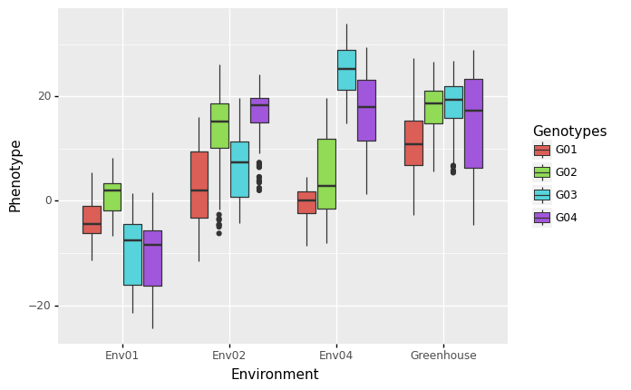

```python
ggplot(df2, aes(x='Environment', y='Phenotype',
               fill='Genotypes')) + geom_boxplot()
```

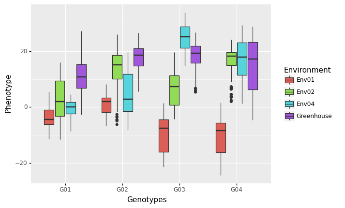

```python
ggplot(df2, aes(x='Genotypes', y='Phenotype',
               fill='Environment')) + geom_boxplot()
```

# Image Processing in Python

Images are commonly used as NumPy arrays. This is because an image is just a matrix of numbers. Almost all computations in scienctific python are done on Numpy arrays. \ Arrays can be n-dimensional. Gray images are usually 2D arrays. RGB images are usually 3D arrays.

## Example using an edge detector (Sobel)

```python
# Import specific functions from a package
from skimage import data, io, filters
```

```python
image = data.coins()
# ... or any other NumPy array!
image
```

```
array([[ 47, 123, 133, ...,  14,   3,  12],
       [ 93, 144, 145, ...,  12,   7,   7],
       [126, 147, 143, ...,   2,  13,   3],
       ...,
       [ 81,  79,  74, ...,   6,   4,   7],
       [ 88,  82,  74, ...,   5,   7,   8],
       [ 91,  79,  68, ...,   4,  10,   7]], dtype=uint8)
```

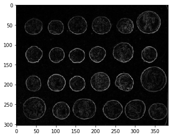

```python
edges = filters.sobel(image)
io.imshow(edges)
```

## Example using thresholding

```python
import matplotlib.pyplot as plt
import matplotlib.patches as mpatches

from skimage import data
from skimage.filters import threshold_otsu
from skimage.segmentation import clear_border
from skimage.measure import label, regionprops
from skimage.morphology import closing, square
from skimage.color import label2rgb
```

```python
# load a subset of the image
image = data.coins()[50:-50, 50:-50]
image
```

```
array([[158, 141, 160, ..., 142, 199, 182],
       [162, 153, 168, ..., 193, 203, 136],
       [178, 173, 173, ..., 143, 179, 120],
       ...,
       [ 98, 117, 143, ...,  64,  65,  66],
       [128, 125, 153, ...,  63,  64,  63],
       [ 99, 102, 132, ...,  66,  62,  59]], dtype=uint8)
```

```python
# Apply threshold (Otsu)
thresh = threshold_otsu(image)
thresh
```

```
112
```

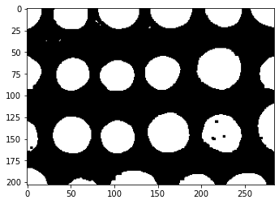

```python
# Apply closing
bw = closing(image > thresh, square(3))
# plt.imshow(bw)
plt.imshow(bw, cmap='gray')
```

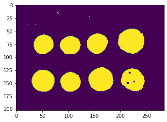

```python
# Remove artifacts connected to image border
cleared = clear_border(bw)
plt.imshow(cleared)
```

```python
# label image regions
label_image = label(cleared)
label_image
# plt.imshow(label_image)
```

```
array([[0, 0, 0, ..., 0, 0, 0],
       [0, 0, 0, ..., 0, 0, 0],
       [0, 0, 0, ..., 0, 0, 0],
       ...,
       [0, 0, 0, ..., 0, 0, 0],
       [0, 0, 0, ..., 0, 0, 0],
       [0, 0, 0, ..., 0, 0, 0]])
```

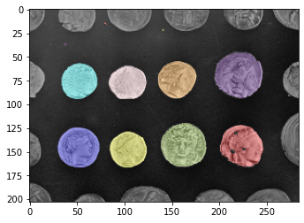

```python
# to make the background transparent, pass the value of `bg_label`,
# and leave `bg_color` as `None` and `kind` as `overlay`
image_label_overlay = label2rgb(label_image, image=image, bg_label=0)
plt.imshow(image_label_overlay)
```

## Region Properties

Requires a labeled image

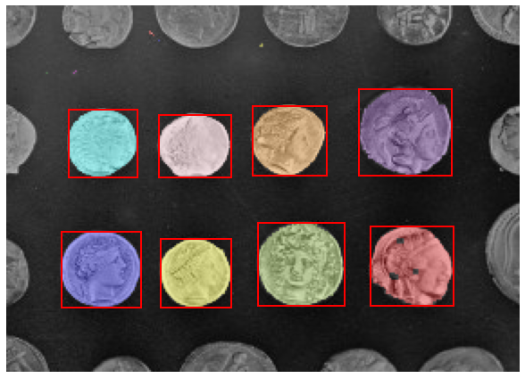

```python
fig, ax = plt.subplots(figsize=(10, 6))
ax.imshow(image_label_overlay)

for region in regionprops(label_image):
    # take regions with large enough areas
    if region.area >= 100:
        # draw rectangle around segmented coins
        minr, minc, maxr, maxc = region.bbox
        rect = mpatches.Rectangle((minc, minr), maxc - minc, maxr - minr,
                                  fill=False, edgecolor='red', linewidth=2)
        ax.add_patch(rect)

ax.set_axis_off()
plt.tight_layout()
plt.show()
```

```python
Props = regionprops(label_image)
# rp
```

```python
# Get data with list comprehensions
Labels = [rp.label for rp in Props]
Areas = [rp.area for rp in Props]
```

```python
Labels
```

```
[1, 2, 3, 4, 5, 6, 7, 8, 9, 10, 11, 12, 13]
```

```python
Image_df = pd.DataFrame()
Image_df['Label'] = Labels
Image_df['Area'] = Areas
Image_df
```

|  | Label | Area |
| --- | --- | --- |
| 0 | 1 | 4 |
| 1 | 2 | 1 |
| 2 | 3 | 3 |
| 3 | 4 | 2 |
| 4 | 5 | 1 |
| 5 | 6 | 1895 |
| 6 | 7 | 1212 |
| 7 | 8 | 1124 |
| 8 | 9 | 1102 |
| 9 | 10 | 1720 |
| 10 | 11 | 1481 |
| 11 | 12 | 1475 |
| 12 | 13 | 1155 |